# Red State Tutorial

# Introduction

> I never said all Democrats are saloon-keepers. What I said is that all saloonkeepers are Democrats. —Horace Greeley, 1860

> Pat doesn’t have a mink coat. But she does have a respectable Republican cloth coat. —Richard Nixon, 1952

> Like upscale areas everywhere, from Silicon Valley to Chicago’s North Shore to suburban Connecticut, Montgomery County supported the Democratic ticket in last year’s presidential election, by a margin of 63 percent to 34 percent. —David Brooks, 2001

> There is, for example, this large class of affluent professionals who are solidly Democratic. DataQuick Information Systems recently put out a list of 100 ZIP code areas where the median home price was above $500,000. By my count, at least 90 of these places — from the Upper West Side to Santa Monica — elect liberal Democrats. —David Brooks, 2004

> A lot of Bush’s red zones can be traced to wealthy enclaves or sun-belt suburbs where tax cuts are king. —Matt Bai, 2001

> But in the Ipsos-Reid surveys, 38% of voters in “strong Bush” counties said that they had household incomes below $30,000, while 7% said that their families earned at least $100,000. In “strong Gore” counties, by contrast, only 29% of voters pegged their household income below $30,000, while 14% said that it was above $100,000. —James Barnes, 2002

For decades, the Democrats have been viewed as the party of the poor, with the Republicans representing the rich. Recent presidential elections, however, have shown a reverse pattern, with Democrats performing well in the richer blue states in the northeast and coasts, and Republicans dominating in the red states in the middle of the country and the south.

The purpose of this homework assignment, then, is to use Stan and hierarchical models to understand this “paradox”. For our purposes, we will use data from the 2004 election.

# Preliminaries

If you haven’t already, please install RStan. Instructions can be found here: https://github.com/stan-dev/rstan/wiki/RStan-Getting-Started.

Then, please download the folder with the data to your desktop. In your R session, you’ll need to set the working directory to this folder.

For Windows, the command to do so will be:

```r
setwd("C:/Users/Public/Desktop/Red State Tutorial")
```

For Macs, the command will be:

```r
setwd("~/Desktop/Red State Tutorial")
```

In addition, you should also run the following commands in your R Session to use RStan and take full advantage of your computer’s processing power. It’ll also add some helper functions that we’ll use later.

```r
library(rstan)
options(mc.cores = parallel::detectCores())
rstan_options(auto_write = TRUE)
source("red_state_tutorial_helper_functions.R")
```

Finally, if you’d like to run the entire code for each scenario, check the appendix.

# Visualizing the “Paradox”

Let’s first try to analyze the data and see if this “paradox” exists. There are two parts to this paradox. The first is that the Democrats are the “party of the poor”. What do we mean when we say that? Well, we expect that people with lower income are more likely to vote Democrat and people with higher income are more likely to vote Republican. Is this the case?

We’ll use the National Annenberg 2004 Election Survey data of 43,970 individuals to explore whether income is positively correlated with voting Republican. In this data set, income is not a continuous variable, but divided into five categories: $0 - $20,000, $20,000 - $40,000, $40,000 - $75,000, $75,000 - $150,000, and $150,000+. Looking at the data, we see:

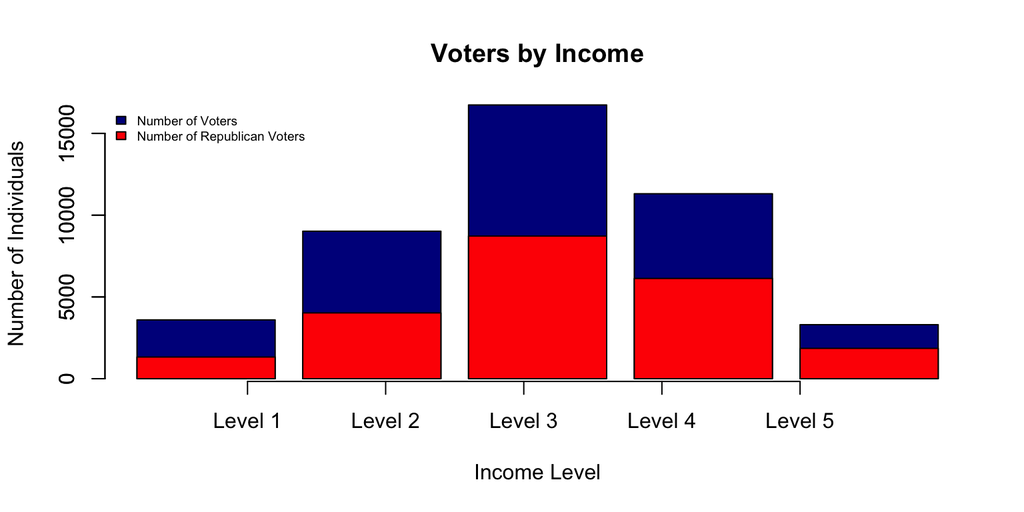

The red and blue boxes in the box graph show the number of the respondents in each income category who voted Republican and Democrat, respectively. While it looks like there are proportionally fewer Republican voters for those in the lowest income level and proportionally more Republican voters for those in the highest income level, the trend isn’t fully clear.

So, let’s analyze it. For simplicity, we’re ignoring third party voters. This means that we can make a binary variable that is 0 if the respondent voted Democrat and 1 if they voted Republican. We can then do a logistic regression with income level as the predictor of voting Republican.

Because income is a categorical variable with five levels, we estimate a regression coefficient for four of the levels and interpret the coefficients relative to the omitted reference level. The intercept of the model can then also be interpreted as representing the lowest income level (alternatively we can think of omitting the intercept and estimating a coefficient for all five of the levels). We’re trying to see if the likelihood of voting Republican increases when income increases, so it makes sense to use the first (i.e. lowest) income level as the reference level.

Now that we know our model, we can use Stan to estimate it. For this example, the Stan code and data for the model are provided. All you have to do is run the model:

```r
load("Data/stan_inc_regression_data.Rdata")

# Use Stan to run the regression model
stan_2004_ind_inc_fit_obj <- stan(file = "Stan/regression_by_one_var.stan",
    data = stan_2004_ind_inc_data, model_name = "Republican vote by individual income")
```

The `stan` function call returns a `stanfit` object. To read more about it, you can visit http://mc-stan.org/interfaces/rstan.html and click on the RStan Manual and Vignette link.

In the Stan code, the regression coefficients for income level are named `b_inc2`, `b_inc3`, `b_inc4`, and `b_inc5`, one for each level between two and five. Again, there isn’t a regression coefficient for the first income level because our other regression coefficients are showing us the difference in outcome between the first income level and them. We can use the `summary` function to pull out the posterior means and 95% credible intervals for the coefficients. Credible intervals are similar to confidence intervals, but they have a more intuitive interpretation in terms of probabilities. Conditional on our model/data/assumptions, we can say that the probability that the $100p\%$ credible interval captures the paramater is $p$. To get the 95% intervals we pull out the 2.5% and 97.5% quantiles.

(The mean is just one possible point estimate to look at. Another common choice is the median. We could also look at other credible intervals. Point estimates and credible intervals are just summaries that help us make inferences and learn from the model, so we can look at whichever ones we think will help us do that.)

```r
# Get the means and 95% intervals
interested_coef <- c("Intercept", "b_inc2", "b_inc3",
    "b_inc4", "b_inc5")
interested_vals <- c("mean", "2.5%", "97.5%")
ind_inc_regression_data <- summary(stan_2004_ind_inc_fit_obj)$summary[interested_coef,
    interested_vals]
```

We didn’t have to save off the information in order to plot it, but we did so to make the plotting code cleaner.

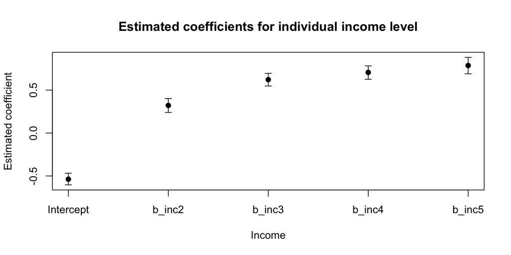

```r
# Plot the regression coefficients with bars
plot(ind_inc_regression_data[, "mean"], ylim = range(c(ind_inc_regression_data[,
    "2.5%"], ind_inc_regression_data[, "97.5%"])),
    pch = 19, xaxt = "n", xlab = "Income", ylab = "Estimated coefficient",
    main = "Estimated coefficients for individual income level")
axis(1, 1:5, interested_coef)
arrows(1:5, ind_inc_regression_data[, "2.5%"], 1:5,
    ind_inc_regression_data[, "97.5%"], length = 0.05,
    angle = 90, code = 3)
```

You’ll notice in the plot that the minimum value is a bit less than $-0.5$ and the largest is a bit less than 1. Clearly, the coefficients do not represent probabilities because probabilities must be between 0 and 1. Because of the transformation used for logistic regression the coefficients are on the log-odds (or logit) scale. The inverse logit function (plotted below) is used to transform real numbers (the $x$-axis in the plot below) to probabilities between 0 and 1 (the $y$-axis):

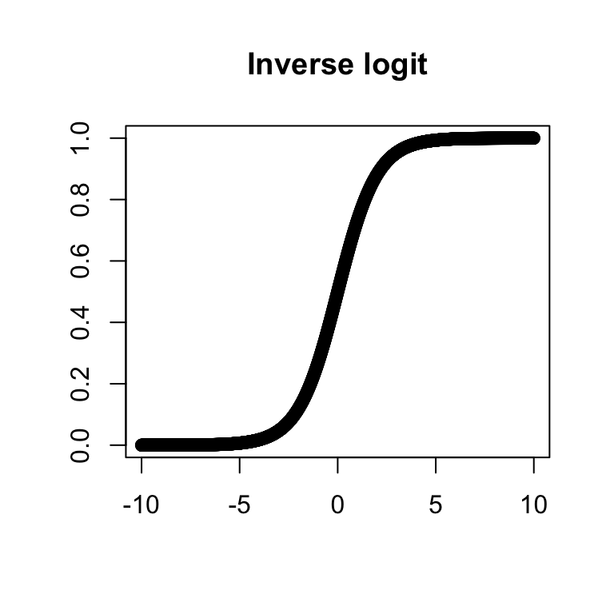

As we can see in the plot, larger coefficients (larger $x$ values) correspond to higher probabilities of voting Republican, though how much of a difference depends on which two points we compare. So, it does look like an increase in an individual’s income is associated with an increase in the probability of voting Republican. This lends supports to the idea that the Democrats are the party of the poor.

However, the other part of the paradox is that the Democrats are the party of the rich states. In other words, are states with higher average income more likely to vote Democrat on average? We can again use a logistic regression model. However, instead of using the 2004 Annenberg Survey data, we’ll be using the Census CPS data. The predictor for this model will be the state average income level, and we can construct it so that there are the same number of states in each income category. The categories are: $0 - $39,000, $39,000 - $43,003, $43,003 - $44,476, $44,476 - $50,614 and $50,614+.

Our model is the same as before so we can reuse the same Stan code and just give Stan the state-level data instead of the individual-level data.

```r
# Get the data and the R package we'll be using for
# the analysis
load("Data/stan_state_regression_data.Rdata")

# Use Stan to run the regression model
stan_2004_state_inc_fit_obj <- stan(file = "Stan/regression_by_one_var.stan",
    data = stan_2004_state_inc_data, model_name = "Republican vote by state average income")
```

We’ll again summarize the data in the same way as before. Only this time, we’ll be doing it using a function instead of looking at the Stanfit object itself.

```r
# Pull out the regression coefficient and the
# information needed for a confidence interval
interested_coef <- c("Intercept", "b_inc2", "b_inc3",
    "b_inc4", "b_inc5")
state_inc_regression_data <- extract_results_from_stanfit_object(interested_coef,
    stan_2004_state_inc_fit_obj)
```

And now, we’ll plot it, but we’ll again use a function that’s wrapping the code called previously.

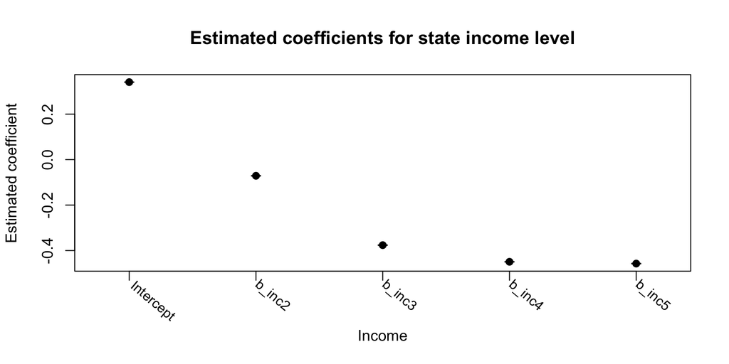

```r
# Plot the coefficients and their 95% credible
# interval bounds
plot_title = "Estimated coefficients for state income level"
plot_coefficients_with_credible_intervals(plot_title,
    interested_coef, state_inc_regression_data)
```

We notice two things in our plot. First, we can’t really see the 95% intervals in this plot because they are much narrower for the coefficients on state average income than individual income. Second, we see that as income level increases, the coefficients decrease. Based on our understanding of the inverse logit function, this means the probability of voting Republican decreases as well.

So from our two models, we can see that as an *individual’s* income increases, the likelihood of voting Republican does so as well, but as a *state’s* average income increases, the likelihood of voting Republican goes down. Let’s now try to understand the paradox.

# Understanding this “paradox”

To get more insight we’ll need to add to our models. As a first stab, for each respondent, we can include his/her individual income and the average income in his/her state as predictors. Our outcome is still a binary indicator for voting Republican so it makes sense to still use a logistic regression.

```r
# Get the data we'll be using for the analysis
load("Data/stan_state_inc_and_ind_inc_regression_data.Rdata")

# Use Stan to run the regression model
stan_2004_state_and_ind_inc_fit_obj <- stan(file = "Stan/regression_by_state_inc_and_ind_inc.stan",
    data = stan_2004_state_and_ind_inc_data, model_name = "Republican vote by state and ind income")
```

For the model, the individual income level regression coefficients are `b_ind_inc2`, `b_ind_inc3`, `b_ind_inc4`, and `b_ind_inc5`, and our state average income level regression coefficients are `b_state_inc2`, `b_state_inc3`, `b_state_inc4`, and `b_state_inc5`. We don’t have regression coefficients for the first or lowest levels because again, we’ve set our model to use the lowest level as the reference categories for comparisons. However, the intercept now represents the effect of the lowest individual income level and lowest state average income level. In other words, it is the coefficient for an individual in the lowest income category from the state with the lowest average income.

```r
# Pull out the regression coefficient and the
# information needed for a credible interval
interested_coef <- c("Intercept", "b_ind_inc2", "b_ind_inc3",
    "b_ind_inc4", "b_ind_inc5", "b_state_inc2", "b_state_inc3",
    "b_state_inc4", "b_state_inc5")
state_and_ind_inc_regression_data <- extract_results_from_stanfit_object(interested_coef,
    stan_2004_state_and_ind_inc_fit_obj)
```

Now, let us plot these estimates.

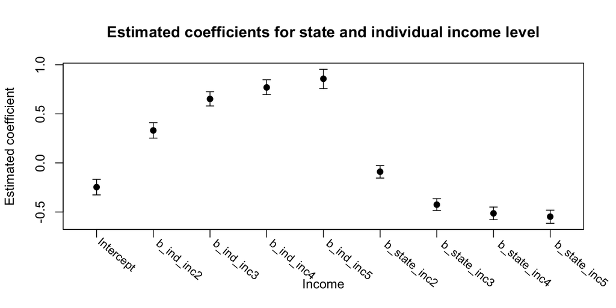

```r
# Plot the coefficients and their 95% credible
# interval bounds
plot_title = "Estimated coefficients for state and individual income level"
plot_coefficients_with_credible_intervals(plot_title,
    interested_coef, state_and_ind_inc_regression_data)
```

So, we haven’t really gotten any more insight into the “paradox”.

Let’s take a step back and think about this problem some more. What do we know?

1. We know that some states are more likely to vote Republican.
2. We know that individuals with higher income are more likely to vote Republican.
3. We know that states with higher average income are less likely to vote Republican.

We can very easily express the first point in a hierarchical or mixed effects model. After all, to say that some states are more likely to vote Republican, we’re also essentially saying that we want the intercept in our regression to vary by state.

Let’s build on this idea. If we can vary the intercept by state, why not also vary the slope associated with an individual’s income by state? (It doesn’t really make sense to vary the slope associated with a state’s average income by state.) In otherwords, does the effect of individual income on voting Republican vary by state?

Let’s conduct this analysis. For this analysis, our outcome will still be the same so we’ll still use a binomial logistic regression model.

```r
load("Data/stan_state_and_inc_regression_data.Rdata")

# Use Stan to run the regression model
model_file = "Stan/mixed_effects_regression_for_state_and_inc.stan"
stan_2004_state_and_inc_fit_obj <- stan(file = model_file,
    data = stan_2004_state_and_income_data, model_name = "Republican vote by income and state")
```

One way to interpret our results is to look at the effect of income for a given state. So, let’s focus on Mississippi, Ohio, and Conneticut because they represent a poor, middle-income, and rich state respectively.

```r
# Pull out the regression coefficient and the
# information needed for a confidence interval
ct_coef <- generate_state_labels(6)
oh_coef <- generate_state_labels(34)
ms_coef <- generate_state_labels(24)
state_and_inc_regression_data <- extract_results_from_stanfit_object(c(ct_coef,
    oh_coef, ms_coef), stan_2004_state_and_inc_fit_obj)
```

Let’s plot the regression coefficients of Mississippi first.

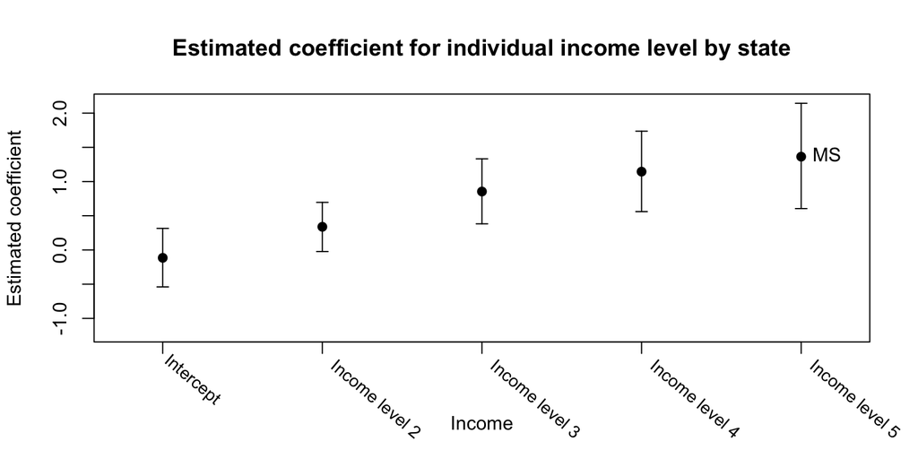

```r
# Plot the regression coefficients with bars Plot
# Mississippi first
plot_title = "Estimated coefficient for individual income level by state"
x_labels = c("Intercept", "Income level 2", "Income level 3",
    "Income level 4", "Income level 5")
plot_coefficients_with_credible_intervals(plot_title,
    x_labels, state_and_inc_regression_data, plot_rows = ms_coef)
text(5, state_and_inc_regression_data[ms_coef[5], "mean"],
    labels = c("MS"), pos = 4)
```

It still looks like the individual income graph from before. What about Ohio, the middle-income state?

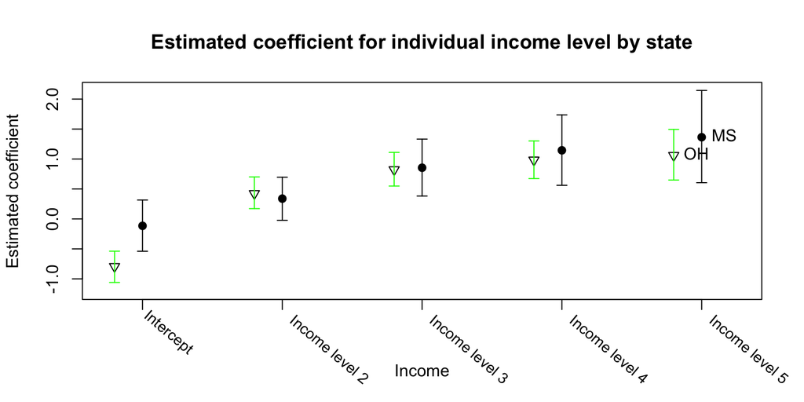

```r
# Plot Ohio
add_state_to_plot("OH", oh_coef, color = "green", state_and_inc_regression_data[oh_coef,
    ], point_offset = -0.2)
```

Huh. It looks like the change in coefficients isn’t as much as before. What about Conneticut, the rich state?

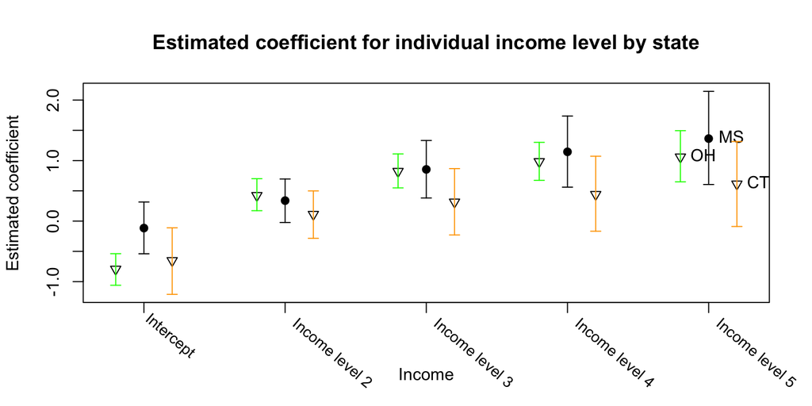

```r
# Plot CT
add_state_to_plot("CT", ct_coef, color = "orange",
    state_and_inc_regression_data[ct_coef, ], point_offset = 0.2)
```

Although individuals with higher incomes are more likely to vote Republican, this trend is less extreme for Connecticut than in Ohio and less extreme for Ohio than Mississippi.

# Conclusion

Let’s take a step back and see what we’ve learned. We sought to understand the paradox that even though the Democrats claim to be the party of the poor, states with higher average income tended to swing Democrat. When we analyzed the 2004 National Election Annenberg Survey data using a binomial logistic regression on individual income level and the number of Republican voters, we did indeed see on our coefficients box plots that the likelihood of voting Republican increases as income level increases. On the other hand, when we analyzed the Census CPS data using a binomial logistic regression on state average income level and the Republican vote share, we saw on our coefficients box plots that the likelihood of voting Republican decreases as average income level increases. So, we confirmed that the paradox seemed to exist.

When we sought to decipher the paradox, we saw that using individual income level and state average income level as predictors model didn’t help. Instead, it was through a hierarchical regression model in which we allowed the intercept and individual income to vary by state. In our coefficient regression plots, we saw that while individuals with higher income are more likely to vote Republican, the effect is smaller in states with higher average income. This explained our paradox.

So, if you enjoy doing this analysis and would like to see this analysis done on other elections, you can read Andrew Gelman, Boris Shor, Joseph Bafumi, and David Park’s *Rich State, Poor State, Red State, Blue State: What’s the Matter with Connecticut?* (from which this tutorial is derived). Or, you could do it yourself and compare your results to their paper.

# Appendix

## Code for Individual Income Model

```r
# Get the data and the R package we'll be using for
# the analysis
library(rstan)
options(mc.cores = parallel::detectCores())
rstan_options(auto_write = TRUE)
source("red_state_tutorial_helper_functions.R")
load("Data/stan_inc_regression_data.Rdata")

# Use Stan to run the regression model
stan_2004_ind_inc_fit_obj <- stan(file = "Stan/regression_by_one_var.stan",
    data = stan_2004_ind_inc_data, model_name = "Republican vote by individual income")

# Plot the coefficients Extract the Stan
# coefficient estimates and their 95% credible
# interval bounds
interested_coef <- c("Intercept", "b_inc2", "b_inc3",
    "b_inc4", "b_inc5")
ind_inc_regression_data <- extract_results_from_stanfit_object(interested_coef,
    stan_2004_ind_inc_fit_obj)

## Plot the coefficients and their 95% credible
## interval bounds
plot_title = "Estimated coefficients for individual income level"
plot_coefficients_with_credible_intervals(plot_title,
    interested_coef, ind_inc_regression_data)
```

## Code for State Income Model

```r
# Get the data and the R package we'll be using for
# the analysis
library(rstan)
options(mc.cores = parallel::detectCores())
rstan_options(auto_write = TRUE)
source("red_state_tutorial_helper_functions.R")

load("Data/stan_state_regression_data.Rdata")

# Use Stan to run the regression model
stan_2004_state_inc_fit_obj <- stan(file = "Stan/regression_by_one_var.stan",
    data = stan_2004_state_inc_data, model_name = "Republican vote by state average income")

# Plot the coefficients Extract the Stan
# coefficient estimates and their 95% credible
# interval bounds
interested_coef <- c("Intercept", "b_inc2", "b_inc3",
    "b_inc4", "b_inc5")
state_inc_regression_data <- extract_results_from_stanfit_object(interested_coef,
    stan_2004_state_inc_fit_obj)

## Plot the coefficients and their 95% credible
## interval bounds
plot_title = "Estimated coefficients for state income level"
plot_coefficients_with_credible_intervals(plot_title,
    interested_coef, state_inc_regression_data)
```

## Code for State and Individual Income Model

```r
# Get the data and the R package we'll be using for
# the analysis
library(rstan)
options(mc.cores = parallel::detectCores())
rstan_options(auto_write = TRUE)
source("red_state_tutorial_helper_functions.R")
load("Data/stan_state_inc_and_ind_inc_regression_data.Rdata")

# Use Stan to run the regression model
model_file = "Stan/regression_by_state_inc_and_ind_inc.stan"
stan_2004_state_and_ind_inc_fit_obj <- stan(file = model_file,
    data = stan_2004_state_and_ind_inc_data, model_name = "Republican vote by state and ind income")

# Plot the coefficients Extract the Stan
# coefficient estimates and their 95% credible
# interval bounds
interested_coef <- c("Intercept", "b_ind_inc2", "b_ind_inc3",
    "b_ind_inc4", "b_ind_inc5", "b_state_inc2", "b_state_inc3",
    "b_state_inc4", "b_state_inc5")
state_and_ind_inc_regression_data <- extract_results_from_stanfit_object(interested_coef,
    stan_2004_state_and_ind_inc_fit_obj)

## Plot the coefficients and their 95% credible
## interval bounds
plot_title = "Estimated coefficients for state and individual income level"
plot_coefficients_with_credible_intervals(plot_title,
    interested_coef, state_and_ind_inc_regression_data)
```

## Code for Hierarchical Model for Individual Income by State

```r
# Get the data and the R package we'll be using for
# the analysis
library(rstan)
options(mc.cores = parallel::detectCores())
rstan_options(auto_write = TRUE)
load("Data/stan_state_and_inc_regression_data.Rdata")

# Use Stan to run the regression model
model_file = "Stan/mixed_effects_regression_for_state_and_inc.stan"
stan_2004_state_and_inc_fit_obj <- stan(file = model_file,
    data = stan_2004_state_and_income_data, model_name = "Republican vote by income and state")

# Pull out the regression coefficient and the
# information needed for a confidence interval
ct_coef <- generate_state_labels(6)
oh_coef <- generate_state_labels(34)
ms_coef <- generate_state_labels(24)
state_and_inc_regression_data <- extract_results_from_stanfit_object(c(ct_coef,
    oh_coef, ms_coef), stan_2004_state_and_inc_fit_obj)

# Plot the regression coefficients with bars Plot
# Mississippi first
plot_title = "Estimated coefficient for individual income level by state"
x_labels = c("Intercept", "Income level 2", "Income level 3",
    "Income level 4", "Income level 5")
plot_coefficients_with_credible_intervals(plot_title,
    x_labels, state_and_inc_regression_data, plot_rows = ms_coef)
text(5, state_and_inc_regression_data[ms_coef[5], "mean"],
    labels = c("MS"), pos = 4)

# Plot Ohio
add_state_to_plot("OH", oh_coef, color = "green", state_and_inc_regression_data[oh_coef,
    ], offset = -0.2)

# Plot Conneticut
add_state_to_plot("CT", ct_coef, color = "orange",
    state_and_inc_regression_data[ct_coef, ], offset = 0.2)
```